# Optimal Treatment Analysis

## Outcome Variable

**Outcome Variable:** haz

## Predictor Variables

**Intervention Variable:** predfeed6

**Adjustment Set:**

- arm
- sex
- month
- brthmon
- W_mage
- meducyrs
- feducyrs
- hhwealth_quart
- hfoodsec
- W_mhtcm
- W_mwtkg
- W_mbmi
- vagbrth
- W_gagebrth
- W_birthwt
- W_birthlen
- W_nrooms
- W_nchldlt5
- W_parity
- impfloor
- impsan
- safeh20
- delta_W_mage
- delta_meducyrs
- delta_feducyrs
- delta_hhwealth_quart
- delta_hfoodsec
- delta_W_mhtcm
- delta_W_mwtkg
- delta_W_mbmi
- delta_vagbrth
- delta_W_gagebrth
- delta_W_birthwt
- delta_W_birthlen
- delta_W_nrooms
- delta_W_nchldlt5
- delta_W_parity
- delta_impfloor
- delta_impsan
- delta_safeh20

## Stratifying Variables

The analysis was stratified on these variable(s):

- agecat
- studyid
- country

## Data Summary

| agecat | studyid | country | predfeed6 | n_cell | n |
| --- | --- | --- | --- | --- | --- |
| Birth | ki0047075b-MAL-ED | BANGLADESH | 1 | 72 | 205 |
| Birth | ki0047075b-MAL-ED | BANGLADESH | 0 | 133 | 205 |
| Birth | ki0047075b-MAL-ED | BRAZIL | 1 | 6 | 60 |
| Birth | ki0047075b-MAL-ED | BRAZIL | 0 | 54 | 60 |
| Birth | ki0047075b-MAL-ED | INDIA | 1 | 4 | 39 |
| Birth | ki0047075b-MAL-ED | INDIA | 0 | 35 | 39 |
| Birth | ki0047075b-MAL-ED | NEPAL | 1 | 3 | 24 |
| Birth | ki0047075b-MAL-ED | NEPAL | 0 | 21 | 24 |
| Birth | ki0047075b-MAL-ED | PERU | 1 | 73 | 213 |
| Birth | ki0047075b-MAL-ED | PERU | 0 | 140 | 213 |
| Birth | ki0047075b-MAL-ED | SOUTH AFRICA | 1 | 1 | 91 |
| Birth | ki0047075b-MAL-ED | SOUTH AFRICA | 0 | 90 | 91 |
| Birth | ki0047075b-MAL-ED | TANZANIA, UNITED REPUBLIC OF | 1 | 0 | 113 |
| Birth | ki0047075b-MAL-ED | TANZANIA, UNITED REPUBLIC OF | 0 | 113 | 113 |
| Birth | ki1000109-EE | PAKISTAN | 1 | 38 | 42 |
| Birth | ki1000109-EE | PAKISTAN | 0 | 4 | 42 |
| Birth | ki1113344-GMS-Nepal | NEPAL | 1 | 419 | 563 |
| Birth | ki1113344-GMS-Nepal | NEPAL | 0 | 144 | 563 |
| Birth | kiGH5241-JiVitA-3 | BANGLADESH | 1 | 12323 | 15793 |
| Birth | kiGH5241-JiVitA-3 | BANGLADESH | 0 | 3470 | 15793 |
| Birth | kiGH5241-JiVitA-4 | BANGLADESH | 1 | 2103 | 2632 |
| Birth | kiGH5241-JiVitA-4 | BANGLADESH | 0 | 529 | 2632 |
| 6 months | ki0047075b-MAL-ED | BANGLADESH | 1 | 84 | 231 |
| 6 months | ki0047075b-MAL-ED | BANGLADESH | 0 | 147 | 231 |
| 6 months | ki0047075b-MAL-ED | BRAZIL | 1 | 30 | 209 |
| 6 months | ki0047075b-MAL-ED | BRAZIL | 0 | 179 | 209 |
| 6 months | ki0047075b-MAL-ED | INDIA | 1 | 11 | 218 |
| 6 months | ki0047075b-MAL-ED | INDIA | 0 | 207 | 218 |
| 6 months | ki0047075b-MAL-ED | NEPAL | 1 | 12 | 225 |
| 6 months | ki0047075b-MAL-ED | NEPAL | 0 | 213 | 225 |
| 6 months | ki0047075b-MAL-ED | PERU | 1 | 92 | 271 |
| 6 months | ki0047075b-MAL-ED | PERU | 0 | 179 | 271 |
| 6 months | ki0047075b-MAL-ED | SOUTH AFRICA | 1 | 3 | 233 |
| 6 months | ki0047075b-MAL-ED | SOUTH AFRICA | 0 | 230 | 233 |
| 6 months | ki0047075b-MAL-ED | TANZANIA, UNITED REPUBLIC OF | 1 | 1 | 232 |
| 6 months | ki0047075b-MAL-ED | TANZANIA, UNITED REPUBLIC OF | 0 | 231 | 232 |
| 6 months | ki1000109-EE | PAKISTAN | 1 | 43 | 48 |
| 6 months | ki1000109-EE | PAKISTAN | 0 | 5 | 48 |
| 6 months | ki1000304b-SAS-FoodSuppl | INDIA | 1 | 0 | 168 |
| 6 months | ki1000304b-SAS-FoodSuppl | INDIA | 0 | 168 | 168 |
| 6 months | ki1113344-GMS-Nepal | NEPAL | 1 | 406 | 547 |
| 6 months | ki1113344-GMS-Nepal | NEPAL | 0 | 141 | 547 |
| 6 months | ki1148112-LCNI-5 | MALAWI | 1 | 47 | 272 |
| 6 months | ki1148112-LCNI-5 | MALAWI | 0 | 225 | 272 |
| 6 months | kiGH5241-JiVitA-3 | BANGLADESH | 1 | 7624 | 9877 |
| 6 months | kiGH5241-JiVitA-3 | BANGLADESH | 0 | 2253 | 9877 |
| 6 months | kiGH5241-JiVitA-4 | BANGLADESH | 1 | 3328 | 4272 |
| 6 months | kiGH5241-JiVitA-4 | BANGLADESH | 0 | 944 | 4272 |
| 24 months | ki0047075b-MAL-ED | BANGLADESH | 1 | 76 | 205 |
| 24 months | ki0047075b-MAL-ED | BANGLADESH | 0 | 129 | 205 |
| 24 months | ki0047075b-MAL-ED | BRAZIL | 1 | 25 | 169 |
| 24 months | ki0047075b-MAL-ED | BRAZIL | 0 | 144 | 169 |
| 24 months | ki0047075b-MAL-ED | INDIA | 1 | 11 | 209 |
| 24 months | ki0047075b-MAL-ED | INDIA | 0 | 198 | 209 |
| 24 months | ki0047075b-MAL-ED | NEPAL | 1 | 12 | 219 |
| 24 months | ki0047075b-MAL-ED | NEPAL | 0 | 207 | 219 |
| 24 months | ki0047075b-MAL-ED | PERU | 1 | 68 | 201 |
| 24 months | ki0047075b-MAL-ED | PERU | 0 | 133 | 201 |
| 24 months | ki0047075b-MAL-ED | SOUTH AFRICA | 1 | 3 | 216 |
| 24 months | ki0047075b-MAL-ED | SOUTH AFRICA | 0 | 213 | 216 |
| 24 months | ki0047075b-MAL-ED | TANZANIA, UNITED REPUBLIC OF | 1 | 1 | 202 |
| 24 months | ki0047075b-MAL-ED | TANZANIA, UNITED REPUBLIC OF | 0 | 201 | 202 |
| 24 months | ki1000109-EE | PAKISTAN | 1 | 20 | 23 |
| 24 months | ki1000109-EE | PAKISTAN | 0 | 3 | 23 |
| 24 months | ki1113344-GMS-Nepal | NEPAL | 1 | 356 | 470 |
| 24 months | ki1113344-GMS-Nepal | NEPAL | 0 | 114 | 470 |
| 24 months | ki1148112-LCNI-5 | MALAWI | 1 | 34 | 189 |
| 24 months | ki1148112-LCNI-5 | MALAWI | 0 | 155 | 189 |
| 24 months | kiGH5241-JiVitA-3 | BANGLADESH | 1 | 3897 | 5048 |
| 24 months | kiGH5241-JiVitA-3 | BANGLADESH | 0 | 1151 | 5048 |
| 24 months | kiGH5241-JiVitA-4 | BANGLADESH | 1 | 3292 | 4199 |
| 24 months | kiGH5241-JiVitA-4 | BANGLADESH | 0 | 907 | 4199 |

The following strata were considered:

- agecat: 24 months, studyid: ki0047075b-MAL-ED, country: BANGLADESH
- agecat: 24 months, studyid: ki0047075b-MAL-ED, country: BRAZIL
- agecat: 24 months, studyid: ki0047075b-MAL-ED, country: INDIA
- agecat: 24 months, studyid: ki0047075b-MAL-ED, country: NEPAL
- agecat: 24 months, studyid: ki0047075b-MAL-ED, country: PERU
- agecat: 24 months, studyid: ki0047075b-MAL-ED, country: SOUTH AFRICA
- agecat: 24 months, studyid: ki0047075b-MAL-ED, country: TANZANIA, UNITED REPUBLIC OF
- agecat: 24 months, studyid: ki1000109-EE, country: PAKISTAN
- agecat: 24 months, studyid: ki1113344-GMS-Nepal, country: NEPAL
- agecat: 24 months, studyid: ki1148112-LCNI-5, country: MALAWI
- agecat: 24 months, studyid: kiGH5241-JiVitA-3, country: BANGLADESH
- agecat: 24 months, studyid: kiGH5241-JiVitA-4, country: BANGLADESH
- agecat: 6 months, studyid: ki0047075b-MAL-ED, country: BANGLADESH
- agecat: 6 months, studyid: ki0047075b-MAL-ED, country: BRAZIL
- agecat: 6 months, studyid: ki0047075b-MAL-ED, country: INDIA
- agecat: 6 months, studyid: ki0047075b-MAL-ED, country: NEPAL
- agecat: 6 months, studyid: ki0047075b-MAL-ED, country: PERU
- agecat: 6 months, studyid: ki0047075b-MAL-ED, country: SOUTH AFRICA
- agecat: 6 months, studyid: ki0047075b-MAL-ED, country: TANZANIA, UNITED REPUBLIC OF
- agecat: 6 months, studyid: ki1000109-EE, country: PAKISTAN
- agecat: 6 months, studyid: ki1000304b-SAS-FoodSuppl, country: INDIA
- agecat: 6 months, studyid: ki1113344-GMS-Nepal, country: NEPAL
- agecat: 6 months, studyid: ki1148112-LCNI-5, country: MALAWI
- agecat: 6 months, studyid: kiGH5241-JiVitA-3, country: BANGLADESH
- agecat: 6 months, studyid: kiGH5241-JiVitA-4, country: BANGLADESH
- agecat: Birth, studyid: ki0047075b-MAL-ED, country: BANGLADESH
- agecat: Birth, studyid: ki0047075b-MAL-ED, country: BRAZIL
- agecat: Birth, studyid: ki0047075b-MAL-ED, country: INDIA
- agecat: Birth, studyid: ki0047075b-MAL-ED, country: NEPAL
- agecat: Birth, studyid: ki0047075b-MAL-ED, country: PERU
- agecat: Birth, studyid: ki0047075b-MAL-ED, country: SOUTH AFRICA
- agecat: Birth, studyid: ki0047075b-MAL-ED, country: TANZANIA, UNITED REPUBLIC OF
- agecat: Birth, studyid: ki1000109-EE, country: PAKISTAN
- agecat: Birth, studyid: ki1113344-GMS-Nepal, country: NEPAL
- agecat: Birth, studyid: kiGH5241-JiVitA-3, country: BANGLADESH
- agecat: Birth, studyid: kiGH5241-JiVitA-4, country: BANGLADESH

### Dropped Strata

Some strata were dropped due to rare outcomes:

- agecat: Birth, studyid: ki0047075b-MAL-ED, country: INDIA
- agecat: Birth, studyid: ki0047075b-MAL-ED, country: NEPAL
- agecat: Birth, studyid: ki0047075b-MAL-ED, country: SOUTH AFRICA
- agecat: Birth, studyid: ki0047075b-MAL-ED, country: TANZANIA, UNITED REPUBLIC OF
- agecat: Birth, studyid: ki1000109-EE, country: PAKISTAN
- agecat: 6 months, studyid: ki0047075b-MAL-ED, country: SOUTH AFRICA
- agecat: 6 months, studyid: ki0047075b-MAL-ED, country: TANZANIA, UNITED REPUBLIC OF
- agecat: 6 months, studyid: ki1000304b-SAS-FoodSuppl, country: INDIA
- agecat: 24 months, studyid: ki0047075b-MAL-ED, country: SOUTH AFRICA
- agecat: 24 months, studyid: ki0047075b-MAL-ED, country: TANZANIA, UNITED REPUBLIC OF
- agecat: 24 months, studyid: ki1000109-EE, country: PAKISTAN

## Methods Detail

We’re interested in the causal parameters $E[Y_a]$ for all values of $a \in \mathcal{A}$. These parameters represent the mean outcome if, possibly contrary to fact, we intervened to set all units to have $A=a$. Under the randomization and positivity assumptions, these are identified by the statistical parameters $\psi_a=E_W[E_{Y|A,W}(Y|A=a,W)]$. In addition, we’re interested in the mean of $Y$, $E[Y]$ under no intervention (the observed mean). We will estimate these parameters by using SuperLearner to fit the relevant likelihood factors – $E_{Y|A,W}(Y|A=a,W)$ and $p(A=a|W)$, and then updating our likelihood fit using a joint TMLE.

For unadjusted analyses ($W=\{\}$), initial likelihoods were estimated using Lrnr_glm to estimate the simple $E(Y|A)$ and Lrnr_mean to estimate $p(A)$. For adjusted analyses, a small library containing Lrnr_glmnet, Lrnr_xgboost, and Lrnr_mean was used.

Having estimated these parameters, we will then use the delta method to estimate relative risks and attributable risks relative to a prespecified baseline level of $A$.

# Results Detail

## Results Plots

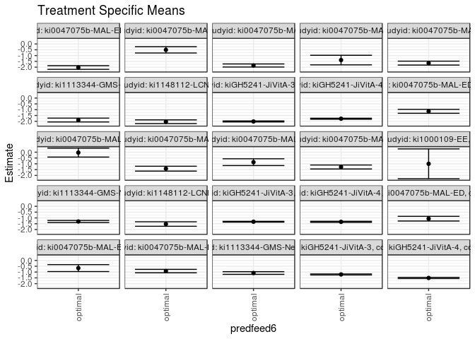

## Results Table

### Parameter: TSM

| agecat | studyid | country | intervention_level | baseline_level | estimate | ci_lower | ci_upper |
| --- | --- | --- | --- | --- | --- | --- | --- |
| Birth | ki0047075b-MAL-ED | BANGLADESH | optimal | observed | -1.0630394 | -1.2650023 | -0.8610764 |
| Birth | ki0047075b-MAL-ED | BRAZIL | optimal | observed | -0.6593115 | -0.9568363 | -0.3617866 |
| Birth | ki0047075b-MAL-ED | PERU | optimal | observed | -0.9164629 | -1.0651064 | -0.7678193 |
| Birth | ki1113344-GMS-Nepal | NEPAL | optimal | observed | -1.0832154 | -1.1991557 | -0.9672750 |
| Birth | kiGH5241-JiVitA-3 | BANGLADESH | optimal | observed | -1.2074622 | -1.2506469 | -1.1642776 |
| Birth | kiGH5241-JiVitA-4 | BANGLADESH | optimal | observed | -1.5078613 | -1.5596950 | -1.4560276 |
| 6 months | ki0047075b-MAL-ED | BANGLADESH | optimal | observed | -1.1398112 | -1.3093447 | -0.9702776 |
| 6 months | ki0047075b-MAL-ED | BRAZIL | optimal | observed | -0.0340861 | -0.4196277 | 0.3514555 |
| 6 months | ki0047075b-MAL-ED | INDIA | optimal | observed | -1.4186341 | -1.6284072 | -1.2088610 |
| 6 months | ki0047075b-MAL-ED | NEPAL | optimal | observed | -0.8591978 | -1.1495671 | -0.5688286 |
| 6 months | ki0047075b-MAL-ED | PERU | optimal | observed | -1.2736984 | -1.4451674 | -1.1022295 |
| 6 months | ki1000109-EE | PAKISTAN | optimal | observed | -0.9995198 | -2.2835589 | 0.2845193 |
| 6 months | ki1113344-GMS-Nepal | NEPAL | optimal | observed | -1.3057936 | -1.3949878 | -1.2165994 |
| 6 months | ki1148112-LCNI-5 | MALAWI | optimal | observed | -1.5253395 | -1.7174390 | -1.3332400 |
| 6 months | kiGH5241-JiVitA-3 | BANGLADESH | optimal | observed | -1.3271447 | -1.3632807 | -1.2910088 |
| 6 months | kiGH5241-JiVitA-4 | BANGLADESH | optimal | observed | -1.3366654 | -1.3832446 | -1.2900861 |
| 24 months | ki0047075b-MAL-ED | BANGLADESH | optimal | observed | -2.0279730 | -2.1847339 | -1.8712120 |
| 24 months | ki0047075b-MAL-ED | BRAZIL | optimal | observed | -0.5075891 | -0.7790042 | -0.2361740 |
| 24 months | ki0047075b-MAL-ED | INDIA | optimal | observed | -1.8534705 | -1.9861040 | -1.7208369 |
| 24 months | ki0047075b-MAL-ED | NEPAL | optimal | observed | -1.3883101 | -1.8019225 | -0.9746977 |
| 24 months | ki0047075b-MAL-ED | PERU | optimal | observed | -1.6495225 | -1.8186474 | -1.4803977 |
| 24 months | ki1113344-GMS-Nepal | NEPAL | optimal | observed | -1.8912668 | -2.0582913 | -1.7242422 |
| 24 months | ki1148112-LCNI-5 | MALAWI | optimal | observed | -2.0374424 | -2.1967557 | -1.8781290 |
| 24 months | kiGH5241-JiVitA-3 | BANGLADESH | optimal | observed | -2.0136822 | -2.0565033 | -1.9708611 |
| 24 months | kiGH5241-JiVitA-4 | BANGLADESH | optimal | observed | -1.7764614 | -1.8203631 | -1.7325596 |

### Parameter: E(Y)

| agecat | studyid | country | intervention_level | baseline_level | estimate | ci_lower | ci_upper |
| --- | --- | --- | --- | --- | --- | --- | --- |
| Birth | ki0047075b-MAL-ED | BANGLADESH | observed | observed | -1.0530244 | -1.1913751 | -0.9146736 |
| Birth | ki0047075b-MAL-ED | BRAZIL | observed | observed | -0.6963333 | -0.9881882 | -0.4044785 |
| Birth | ki0047075b-MAL-ED | PERU | observed | observed | -0.9065728 | -1.0297267 | -0.7834188 |
| Birth | ki1113344-GMS-Nepal | NEPAL | observed | observed | -1.0641208 | -1.1525364 | -0.9757052 |
| Birth | kiGH5241-JiVitA-3 | BANGLADESH | observed | observed | -1.2156259 | -1.2478377 | -1.1834141 |
| Birth | kiGH5241-JiVitA-4 | BANGLADESH | observed | observed | -1.5273138 | -1.5765339 | -1.4780937 |
| 6 months | ki0047075b-MAL-ED | BANGLADESH | observed | observed | -1.1905988 | -1.3103463 | -1.0708514 |
| 6 months | ki0047075b-MAL-ED | BRAZIL | observed | observed | 0.0510207 | -0.0930194 | 0.1950608 |
| 6 months | ki0047075b-MAL-ED | INDIA | observed | observed | -1.2185703 | -1.3422027 | -1.0949380 |
| 6 months | ki0047075b-MAL-ED | NEPAL | observed | observed | -0.5616889 | -0.6770008 | -0.4463770 |
| 6 months | ki0047075b-MAL-ED | PERU | observed | observed | -1.3264945 | -1.4355111 | -1.2174779 |
| 6 months | ki1000109-EE | PAKISTAN | observed | observed | -2.1595486 | -2.5331781 | -1.7859192 |
| 6 months | ki1113344-GMS-Nepal | NEPAL | observed | observed | -1.3540280 | -1.4334801 | -1.2745760 |
| 6 months | ki1148112-LCNI-5 | MALAWI | observed | observed | -1.6395956 | -1.7592633 | -1.5199278 |
| 6 months | kiGH5241-JiVitA-3 | BANGLADESH | observed | observed | -1.3370052 | -1.3650190 | -1.3089913 |
| 6 months | kiGH5241-JiVitA-4 | BANGLADESH | observed | observed | -1.3482303 | -1.3866421 | -1.3098185 |
| 24 months | ki0047075b-MAL-ED | BANGLADESH | observed | observed | -1.9581707 | -2.0862906 | -1.8300508 |
| 24 months | ki0047075b-MAL-ED | BRAZIL | observed | observed | 0.0071006 | -0.1615817 | 0.1757828 |
| 24 months | ki0047075b-MAL-ED | INDIA | observed | observed | -1.8848804 | -2.0154334 | -1.7543274 |
| 24 months | ki0047075b-MAL-ED | NEPAL | observed | observed | -1.3232192 | -1.4452887 | -1.2011496 |
| 24 months | ki0047075b-MAL-ED | PERU | observed | observed | -1.7544776 | -1.8753255 | -1.6336298 |
| 24 months | ki1113344-GMS-Nepal | NEPAL | observed | observed | -1.9002128 | -1.9869255 | -1.8135001 |
| 24 months | ki1148112-LCNI-5 | MALAWI | observed | observed | -1.9651323 | -2.1053230 | -1.8249415 |
| 24 months | kiGH5241-JiVitA-3 | BANGLADESH | observed | observed | -2.0173019 | -2.0536076 | -1.9809962 |
| 24 months | kiGH5241-JiVitA-4 | BANGLADESH | observed | observed | -1.7914765 | -1.8297816 | -1.7531715 |

### Parameter: PAR

| agecat | studyid | country | intervention_level | baseline_level | estimate | ci_lower | ci_upper |
| --- | --- | --- | --- | --- | --- | --- | --- |
| Birth | ki0047075b-MAL-ED | BANGLADESH | optimal | observed | 0.0100150 | -0.1455337 | 0.1655637 |
| Birth | ki0047075b-MAL-ED | BRAZIL | optimal | observed | -0.0370219 | -0.1538328 | 0.0797891 |
| Birth | ki0047075b-MAL-ED | PERU | optimal | observed | 0.0098901 | -0.1030760 | 0.1228562 |
| Birth | ki1113344-GMS-Nepal | NEPAL | optimal | observed | 0.0190946 | -0.0759898 | 0.1141790 |
| Birth | kiGH5241-JiVitA-3 | BANGLADESH | optimal | observed | -0.0081637 | -0.0334514 | 0.0171240 |
| Birth | kiGH5241-JiVitA-4 | BANGLADESH | optimal | observed | -0.0194525 | -0.0476813 | 0.0087762 |
| 6 months | ki0047075b-MAL-ED | BANGLADESH | optimal | observed | -0.0507877 | -0.1863344 | 0.0847590 |
| 6 months | ki0047075b-MAL-ED | BRAZIL | optimal | observed | 0.0851068 | -0.2663885 | 0.4366022 |
| 6 months | ki0047075b-MAL-ED | INDIA | optimal | observed | 0.2000638 | 0.0218300 | 0.3782976 |
| 6 months | ki0047075b-MAL-ED | NEPAL | optimal | observed | 0.2975090 | 0.0251704 | 0.5698475 |
| 6 months | ki0047075b-MAL-ED | PERU | optimal | observed | -0.0527960 | -0.1944807 | 0.0888887 |
| 6 months | ki1000109-EE | PAKISTAN | optimal | observed | -1.1600288 | -2.3949122 | 0.0748546 |
| 6 months | ki1113344-GMS-Nepal | NEPAL | optimal | observed | -0.0482344 | -0.0979154 | 0.0014466 |
| 6 months | ki1148112-LCNI-5 | MALAWI | optimal | observed | -0.1142561 | -0.2586421 | 0.0301299 |
| 6 months | kiGH5241-JiVitA-3 | BANGLADESH | optimal | observed | -0.0098604 | -0.0335793 | 0.0138584 |
| 6 months | kiGH5241-JiVitA-4 | BANGLADESH | optimal | observed | -0.0115650 | -0.0413734 | 0.0182434 |
| 24 months | ki0047075b-MAL-ED | BANGLADESH | optimal | observed | 0.0698022 | -0.0423617 | 0.1819661 |
| 24 months | ki0047075b-MAL-ED | BRAZIL | optimal | observed | 0.5146897 | 0.2444378 | 0.7849416 |
| 24 months | ki0047075b-MAL-ED | INDIA | optimal | observed | -0.0314099 | -0.0743791 | 0.0115593 |
| 24 months | ki0047075b-MAL-ED | NEPAL | optimal | observed | 0.0650909 | -0.3173380 | 0.4475198 |
| 24 months | ki0047075b-MAL-ED | PERU | optimal | observed | -0.1049551 | -0.2388963 | 0.0289862 |
| 24 months | ki1113344-GMS-Nepal | NEPAL | optimal | observed | -0.0089460 | -0.1391762 | 0.1212842 |
| 24 months | ki1148112-LCNI-5 | MALAWI | optimal | observed | 0.0723101 | -0.0131004 | 0.1577206 |
| 24 months | kiGH5241-JiVitA-3 | BANGLADESH | optimal | observed | -0.0036197 | -0.0267843 | 0.0195448 |
| 24 months | kiGH5241-JiVitA-4 | BANGLADESH | optimal | observed | -0.0150152 | -0.0370219 | 0.0069915 |